# 禅中看缠 (Zen Plugin) — 用户手册 V1.7

> **授人以鱼，不如授人以渔。** 一个**系统化落地**缠论核心概念（分型、笔、线段、中枢、背驰、买卖点）、又**支持自定义**配置细节的缠论学习研究工具。

## 目录

- 第一部分：通达信 DLL 插件（Windows）
  - 1.1 安装与部署
    - 1.1.1 第一阶段：下载并安装通达信
    - 1.1.2 第二阶段：部署禅中看缠插件
    - 1.1.3 第三阶段：导入缠论公式
    - 1.1.4 卸载插件
  - 1.2 首次运行与授权
    - 1.2.1 获取机器码
    - 1.2.2 完成授权
  - 1.3 公式使用方法
    - 1.3.1 模式开关
      - 1.3.1.1 完整组合表
    - 1.3.2 绘图公式
      - 1.3.2.1 指标参数设置
      - 1.3.2.2 信号代码含义
    - 1.3.3 插件选股（极速选股）
      - 1.3.3.1 参数配置表
      - 1.3.3.2 跨级别组合选股（多周期共振）
  - 1.4 关于绘图公式
    - 1.4.1 funcid 功能索引
    - 1.4.2 常用公式配置组合
    - 1.4.3 关于缠论分析的 K 线数量
  - 1.5 禅中看缠回测工具
    - 1.5.1 适用场景
    - 1.5.2 授权与试用
    - 1.5.3 使用方法
    - 1.5.4 分析参数
    - 1.5.5 逐根推送与整体推送
    - 1.5.6 交易模拟（买卖回测）
- 第二部分：桌面版
  - 2.1 安装与部署
  - 2.2 首次运行与授权
    - 2.2.1 获取机器码
    - 2.2.2 完成授权
    - 2.2.3 试用期说明
  - 2.3 界面说明
    - 2.3.1 开关说明
    - 2.3.2 周期切换与自选股
    - 2.3.3 K线图操作
  - 2.4 数据源
- 第三部分：安卓版
  - 3.1 安装与部署
  - 3.2 首次运行与授权
    - 3.2.1 获取机器码与完成授权
  - 3.3 界面说明
    - 3.3.1 K线图操作
- 附录
  - 附录 A.1 模式开关详解
  - 附录 A.2 授权等级
  - 附录 A.3 通达信 DLL 绑定说明
  - 附录 A.4 通达信盘后数据下载说明

## 第一部分：通达信 DLL 插件（Windows）

### 1.1 安装与部署

**版本兼容说明**

本插件通过通达信公式系统加载使用，兼容标准：通达信 7.42 及以上版本、且**未禁用 DLL 绑定功能的 Windows 版本**。

- 官网版通达信金融终端 7.42+：完整支持（32/64 位）
- **券商定制版**：多数券商用的就是通达信（华泰、中信、招商、银河、国泰君安等），原则上也能用。但头部券商往往改了自己的主程序名（如中信 `ecitic.exe`、招商 `newone.exe`），而**自动安装脚本只认标准名 `tdxw.exe`**，这种情况请按「方法二」手工安装。个别券商把 DLL 绑定功能阉割了，那就用不了——按「方法二」装完打开主图试一下即可判断：能正常显示缠论分析就是兼容，提示插件无法加载或公式报 TDXDLL2 相关错误就是不支持。
- 不支持：非通达信的行情软件（同花顺、东方财富等）及手机版。

#### 1.1.1 第一阶段：下载并安装通达信

从通达信官网下载并安装通达信金融终端（需 7.42 及以上版本）。目前主流电脑**推荐使用 64 位版本**。

[figure not shown]

下载 32 位通达信后是下图的第一个文件，下载 64 位通达信（推荐）则是下图的第二个文件。

[figure not shown]

32 位和 64 位版本的通达信只需要下载一个双击安装即可，不要都装。**安装路径请注意尽量不要包含中文字符**，最好就用其默认提供的路径。如果想装到其他盘符（如 D:、E:），在安装时修改路径头部字母即可。

- 32 位通达信默认安装在 `C:\new_tdx`
- 64 位通达信默认安装在 `C:\new_tdx64`

[figure not shown]

[figure not shown]

#### 1.1.2 第二阶段：部署禅中看缠插件

本插件提供**自动安装（推荐）** 与 **手工安装** 两种方式，最终效果完全相同。无论选择哪种方式，安装完成后都必须继续阅读下一节 1.1.3 第三阶段：导入缠论公式 完成最后的公式导入。

##### 方法一：自动安装（推荐）

安装脚本会自动完成插件文件的复制部署与插件绑定（操作步骤参见下方「方法二」），无需手动定位目录、复制文件或配置绑定。

注意事项：

- 安装脚本会**自动请求管理员权限**（双击运行后弹出"用户账户控制"提示时点击"是"即可），因为它要向通达信的系统目录写入文件并创建子目录。没有管理员权限会被 Windows 拒绝。

操作步骤：

1. 从发布页面下载插件压缩包并解压。（最好避免路径中出现中文）**请注意选择与通达信版本匹配的插件**（32 位或 64 位），否则无法使用。
2. 找到并**双击**运行 `双击我_进行安装或升级.bat`，若弹出"用户账户控制"提示时点击 **"是"**。脚本会自动识别当前DLL插件版本并匹配对应的通达信。
3. 脚本会自动找到通达信的安装位置，完成插件文件的复制、绑定与核对。（找不到或位数不匹配时会提示你手工输入 `32` 或 `64`）**必须看到脚本最后的 "安装/升级完成!" 提示才算成功**，然后按任意键关闭窗口。
   - 如果窗口**一闪而过**或中途报错退出，说明安装没有成功，请改按下方「方法二：手工安装」完成安装。
4. 脚本会自动完成 DLL 插件与通达信的绑定（`dlls.ini` 已放入通达信下的 `T0002\dlls` 目录），**无需再手工绑定**；接下来的公式导入请继续阅读 1.1.3 第三阶段：导入缠论公式。
5. 升级安装的用户可确认版本号：登录通达信时留意授权弹窗左上角显示的版本号；或按「方法二」找到 `tdx_zen.dll` 所在目录，右键该文件 → 属性 → 详细信息查看"文件版本"。

##### 方法二：手工安装

1. 从发布页面下载插件压缩包并解压。（最好避免路径中出现中文）**请注意选择与通达信版本匹配的插件**（32 位或 64 位），否则无法使用。
2. 将压缩包内的 `tdx_zen.dll`，`dlls.ini`，`tdx_zen.tn6` 3个文件都复制到通达信安装目录下的 `T0002\dlls\` 子目录中：
   - 例如：`C:\new_tdx\T0002\dlls\`（32 位）
   - 或者：`C:\new_tdx64\T0002\dlls\`（64 位）
3. 将压缩包内的 `tdx_zen.dll` 文件同时复制到通达信安装目录下的 `plugin` 子目录下，**如果没有此目录请手工新建**。注意该 `plugin` 目录是和 `T0002` 目录平行的，不要建在 `T0002` 下面。
   - 例如：`C:\new_tdx\plugin\`（32 位）
   - 或者：`C:\new_tdx64\plugin\`（64 位）
4. 将 `zen_license.key` 授权文件（**3 天免费试用不需要此步骤**，获得正式授权时再进行此步骤）放到通达信安装目录下的上述 `T0002\dlls` 和 `plugin` 两个子目录下，也就是和插件文件 `tdx_zen.dll` 要在同一目录里。

#### 1.1.3 第三阶段：导入缠论公式

上节如果已经把 `dlls.ini` 文件放到了 `dlls` 目录，插件的绑定工作已经自动完成（自动安装方式同样已由脚本完成绑定）。如果因为通达信版本功能变化绑定没有成功，请参照 附录 A.3 通达信 DLL 绑定说明 进行手工绑定。

1. 启动通达信软件，按下 **`Ctrl + F`** 打开公式管理器。
2. 点击右侧的 **"导入公式"** 按钮，选中上节 `dlls` 目录下的 `tdx_zen.tn6` 文件导入；**升级安装时同样需要重新导入** `tdx_zen.tn6` 并覆盖同名公式。

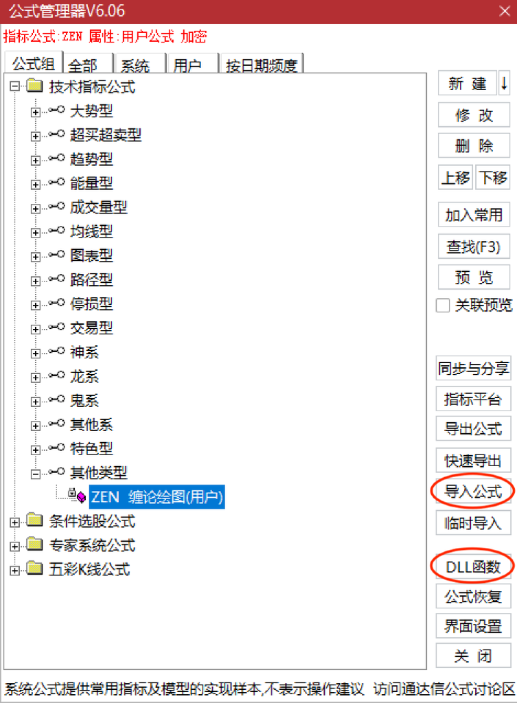

[figure not shown]

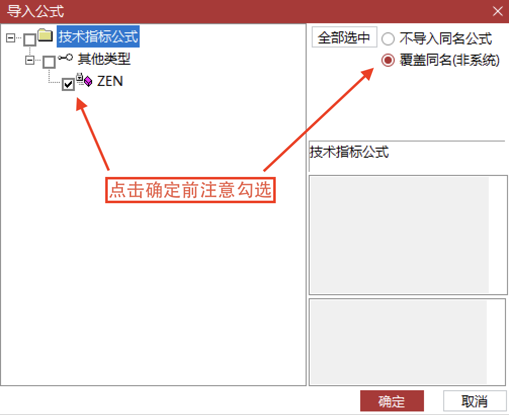

3. 导入缠论主图公式（名为 `ZEN`），在行情界面输入该公式名称即可使用。

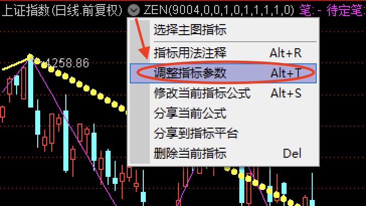

#### 1.1.4 卸载插件

当不需要此插件时按照下述步骤从电脑中彻底移除。

1. 删除 `T0002\dlls\` 下的 `tdx_zen.dll`、`dlls.ini`、`tdx_zen.tn6` 和 `zen_license.key` 文件（如有）。
2. 删除通达信安装目录下 `plugin\` 中的 `tdx_zen.dll` 和 `zen_license.key` 文件（如有）。
3. 公式管理器中（按下 **`Ctrl + F`**）删除已导入的缠论公式 'ZEN'。

⬆ 回到目录

### 1.2 首次运行与授权

完成了 1.1 节的安装后就可以重启通达信了，登录时会有如下弹窗（通过浏览器打开的页面，请注意是否在状态栏中）：

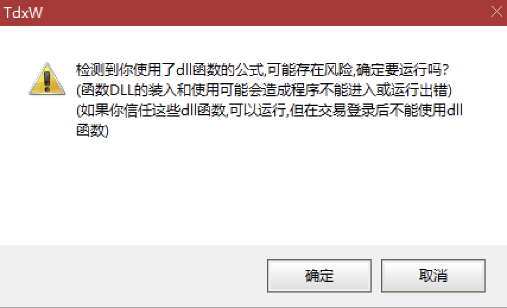

需要**连续点击两次确认**进入通达信主界面。插件是通达信官方允许的拓展模式，但是会提醒用户知晓正在使用插件。

登录后，首次运行会有如下弹窗协议，必须**滚动到协议最后阅读全文点击同意**后方可继续使用。如果点击取消或者关闭该弹窗页面将视为不同意，无法继续使用。如果不小心关闭了弹窗，重新启动登录通达信即可再次出现。一旦点击了同意将不再显示该协议；只有在软件升级、且新版改动过协议正文时，才会再次弹窗请你重新阅读同意——仅升级而协议正文没有变化，不会再弹。

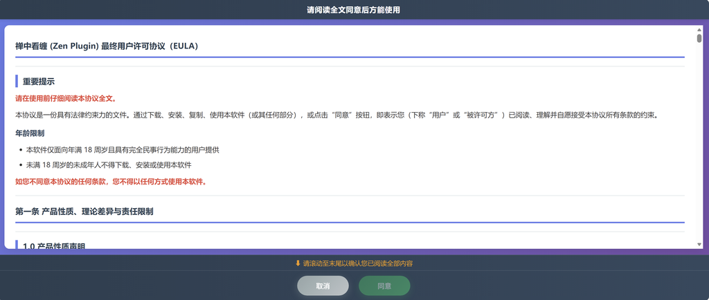

如果你的电脑没有弹出协议，或者无法点击同意按钮等问题，请加入QQ群（压缩包内的 README.html 文件中有群号）联系作者协助处理（作者邮箱以软件授权弹窗中显示为准）。

#### 1.2.1 获取机器码

试用期间，插件每次启动通达信都会自动弹窗显示机器码（格式 `zen-xxxxxxxx-xxxxxxxx`），机器码会自动复制到剪贴板。将机器码发送给作者获取授权文件。放入授权文件后，授权文件每次发生变化都会弹一次剩余时间提醒；此外授权到期前 7 天内每次启动通达信都会提醒一次（这条剩余时间提醒只在主图分析时弹，插件选股时不弹，免得每换一只股票都打扰一次），授权已过期或失效时同样每次启动都会提示。弹窗在同一次启动内只出现一次，不会反复打扰；不在上述时间窗口内时不会弹窗干扰客户使用。

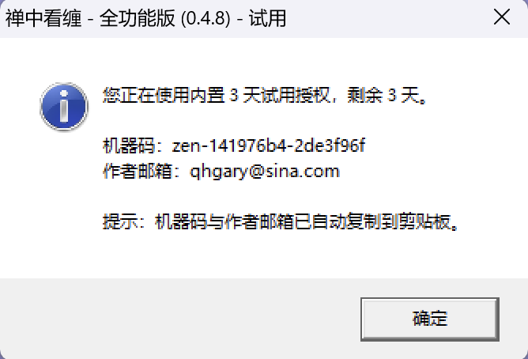

#### 1.2.2 完成授权

将获取到的 `zen_license.key` 授权文件放到 `T0002\dlls\` 和 `plugin` 目录下（与 DLL 文件在同一目录），重新打开通达信即可生效。`T0002\dlls\` 用于主图分析，`plugin\` 用于插件选股，两个目录都需要放置 `zen_license.key`。

> **试用期**：无授权文件时，可无限制使用 **3 天试用期**。试用需联网校准时间，长期断网时无法激活和推进试用进度。请注意，一旦放入授权文件，试用期立即结束，无法再回到试用模式。

> **联网是使用本插件的前提，不区分试用与正式授权**：插件每次启动都要通过网络校准时间来核对有效期，因此断网期间无论使用哪种授权（**永久授权也一样**）都无法进行缠论分析，恢复联网后自动恢复，无需重新输入授权。若机器已连上网络却仍提示"无法验证授权有效期"，通常是 VPN 干扰了时间校准，关掉 VPN 再启动即可。

各等级开放的内容见 附录 A.2 授权等级。

⬆ 回到目录

### 1.3 公式使用方法

> 使用默认配置即可，不准备修改模式的可以忽略本章节的详细说明。

#### 1.3.1 模式开关

公式的 **模式开关** 参数是一个数字，默认 **9004**。日常使用不必管它是怎么算出来的，只要知道它是五个开关的组合：**`模式开关 = 9000 + 各开关数值之和`**，每个开关对应一个数，想开哪几个，就把哪几个数加起来，再加 9000。

> 这五个开关都不是"谁对谁错"，而是缠论原文没有写死、各家各派做法不同的几处。下面逐个说明它们管什么，具体怎么选按你自己的看盘习惯来，拿不定主意就用默认的 9004。

**缺口成笔（+1）**：跳空缺口算不算一笔。打开后，跳空越过前一笔起点时也算成笔——跳空多的地方会多出笔来，不会因为中间少几根 K 线就把一整段漏掉。日线以上跳空多、觉得漏笔时打开；只看分钟级别可以不开。

**新笔成笔（+2）**：放宽"一笔至少要几根 K 线"。不开（默认）是**老笔**口径：顶分型与底分型不能共用 K 线，两个极点之间（含两端）至少要有 5 根独立 K 线。打开是**新笔**口径，出自缠师 2007-09-18 的博文《忽闻台风可休市，聊赋七律说〈风灾〉》：顶分型与底分型仍然不能共用 K 线，但只要两个极点之间（不含两端、不考虑包含关系）至少有 3 根原始 K 线就算一笔。新笔口径下，K 线密集、包含关系多的股票会明显多出一些笔，走势跟价格贴得更紧；不开就是老笔口径，笔更少更粗。

**中枢拓展（+4）**：中枢被离开之后又回到区间里、此时还没形成新中枢，这一段算不算原中枢的一部分。算：中枢往右延续，图上中枢更少、更大；不算的话中枢更早结束，图上会出现更多、更小的中枢。

**中枢扩张（+8，打开会自动带上拓展）**：相邻两个中枢的波动区间有交叠、而中枢区间并没有交叠时，是否直接在本级别认为它们已经合成一个更大级别的中枢（原文「走势中枢中心定理二」讲的就是这一支）。合并：本周期图上中枢更少更大，细节被大中枢吃掉；不合并（默认）就保留本级别的细节，想看合成后的大中枢，换到高一级别的周期去看。

**允许跨界（+16）**：笔中枢能不能跨过线段边界继续延伸。打开后笔中枢更少、信号也更少；关闭（推荐）则笔中枢只在线段内生长，结构更细。

> **这几个「中枢」开关说的是哪一层**：图上同时画着笔中枢和线段中枢。三个中枢开关里，**「允许跨界」只对笔中枢起作用**——线段中枢上面没有更大的框，本来就不存在"跨不跨边界"这回事。**拓展和扩张是两层共用一个开关**，开关一拨，笔中枢和线段中枢都跟着变。平时看着好像只有笔中枢在动，是因为 420 根 K 里线段通常只有几段，连第二个线段中枢都凑不出来，而扩张至少要两个中枢才谈得上——这是数据太短，不是线段中枢不受控制。

> **算数字**：把要开的开关对应的数加起来，再加 9000。默认 9004 就是只开拓展；再加扩张（8）是 **9012**；再加跨界（16）是 **9028**；反过来只想开缺口成笔、其余全关就是 9001。

> **扩张依赖拓展**：打开扩张时拓展会跟着打开（填数字时程序也会自动补上拓展）；桌面版、安卓版与回测工具的开关按钮还会在关掉拓展时连带关掉扩张。所以"扩张开、拓展关"这个组合不存在，那几个数字不用去记。

> **默认 9004**：只开拓展，缺口成笔、新笔成笔、扩张、跨界都关着，笔按老笔口径划。看不懂这些开关、也不知道该用哪个的，直接用默认值就行。

> **完整组合表**：下面这张表是给想自己核对数字的人备查的，日常按上面的说明挑就够，不必逐个看；灰色几行就是"扩张开、拓展关"的不存在组合，填了也会被自动纠正成拓展开着的那一档。

##### 1.3.1.1 完整组合表

| 模式开关 | 开关合计 | 缺口 | 新笔 | 拓展 | 扩张 | 跨界 |
| --- | --- | --- | --- | --- | --- | --- |
| 9000 | 0 | ❌ | ❌ | ❌ | ❌ | ❌ |
| 9001 | 1 | ✅ | ❌ | ❌ | ❌ | ❌ |
| 9002 | 2 | ❌ | ✅ | ❌ | ❌ | ❌ |
| 9003 | 3 | ✅ | ✅ | ❌ | ❌ | ❌ |
| **9004** | **4** | ❌ | ❌ | ✅ | ❌ | ❌ |
| 9005 | 5 | ✅ | ❌ | ✅ | ❌ | ❌ |
| 9006 | 6 | ❌ | ✅ | ✅ | ❌ | ❌ |
| 9007 | 7 | ✅ | ✅ | ✅ | ❌ | ❌ |
| 9008 | 8 | ❌ | ❌ | ❌ | ✅ | ❌ |
| 9009 | 9 | ✅ | ❌ | ❌ | ✅ | ❌ |
| 9010 | 10 | ❌ | ✅ | ❌ | ✅ | ❌ |
| 9011 | 11 | ✅ | ✅ | ❌ | ✅ | ❌ |
| 9012 | 12 | ❌ | ❌ | ✅ | ✅ | ❌ |
| 9013 | 13 | ✅ | ❌ | ✅ | ✅ | ❌ |
| 9014 | 14 | ❌ | ✅ | ✅ | ✅ | ❌ |
| 9015 | 15 | ✅ | ✅ | ✅ | ✅ | ❌ |
| 9016 | 16 | ❌ | ❌ | ❌ | ❌ | ✅ |
| 9017 | 17 | ✅ | ❌ | ❌ | ❌ | ✅ |
| 9018 | 18 | ❌ | ✅ | ❌ | ❌ | ✅ |
| 9019 | 19 | ✅ | ✅ | ❌ | ❌ | ✅ |
| 9020 | 20 | ❌ | ❌ | ✅ | ❌ | ✅ |
| 9021 | 21 | ✅ | ❌ | ✅ | ❌ | ✅ |
| 9022 | 22 | ❌ | ✅ | ✅ | ❌ | ✅ |
| 9023 | 23 | ✅ | ✅ | ✅ | ❌ | ✅ |
| 9024 | 24 | ❌ | ❌ | ❌ | ✅ | ✅ |
| 9025 | 25 | ✅ | ❌ | ❌ | ✅ | ✅ |
| 9026 | 26 | ❌ | ✅ | ❌ | ✅ | ✅ |
| 9027 | 27 | ✅ | ✅ | ❌ | ✅ | ✅ |
| 9028 | 28 | ❌ | ❌ | ✅ | ✅ | ✅ |
| 9029 | 29 | ✅ | ❌ | ✅ | ✅ | ✅ |
| 9030 | 30 | ❌ | ✅ | ✅ | ✅ | ✅ |
| 9031 | 31 | ✅ | ✅ | ✅ | ✅ | ✅ |

> 新笔成笔与缺口成笔互不影响，满足其一即可成笔。

#### 1.3.2 绘图公式

在通达信中，绘图公式用于在行情界面显示缠论分析效果。输入公式名称 `ZEN` 即可在主图上显示完整的缠论分析结果。

##### 1.3.2.1 指标参数设置

公式共有 10 个指标参数可供调整，分两类：

- **分析与显示类 3 个**：`模式开关`、`笔端极值`、`缠K显隐`，见下表。
- **绘制类 7 个**：`笔显隐`、`笔价显隐`、`线段显隐`、`笔枢显隐`、`段枢显隐`、`MACD背离显隐`、`缠K背景色`（排在参数列表最后），各自控制绘制内容的显隐或配色，取值含义与默认值见 1.4.2 常用公式配置组合 的开关表。这 7 个原先写在公式内容顶部，现在已经和上面三个一样成为指标参数，**不需要改动公式内容**。

> **调参提示**：`模式开关` 与 `笔端极值` 会改变主图分析结果（笔、线段、中枢、买卖点都随之变化），除非明确了解其含义，否则不要随意更改；其余 8 个参数里，7 个绘制开关只影响界面呈现，`缠K显隐` 只影响K线怎么显示，都不参与主图分析计算，可按需自由调整。

| 参数 | 说明 | 默认值 |
| --- | --- | --- |
| **模式开关** | 分析模式选择，控制各个开关的组合（见上文） | 9004 |
| **笔端极值** | 笔的起点和终点是否都要是这一笔内的极值：0=都不要求（默认），1=只要求终点，2=起点和终点都要（取值范围 `0~2`） | 0 |
| **缠K显隐** | K线显示方式：0=显示通达信原始K线（默认），1=绘制缠论合并K线。只影响显示，不改变任何分析结果 | 0 |

另外还有两个设置**不在指标参数里**，而是写在公式内容开头，改完保存并重新应用公式即可生效（与改参数一样会立即重新计算）：

| 设置 | 公式中的写法 | 说明 | 默认值 |
| --- | --- | --- | --- |
| **推送方式** | `推送方式:=1;` | 处理模式选择：1=逐根推送，0=整体推送 | 1 |
| **选股K线数** | `选股K线数:=420;` | 插件选股请求的K线根数，只影响选股、不影响主图（取值范围 `120~2000`），一般无需改动；含义与调整方法见 1.3.3 插件选股（极速选股） | 420 |

**推送方式说明**（取值写在公式内容里，0 和 1 的含义如下）：

- **逐根推送（推送方式=1，默认）**：逐根 K 线推送进行分析，贴合缠论逐根生长的动态识别方式。已确认的历史结构不会被修改，确保信号不会因后续数据变化而反复变动（只有与最新行情相接的那一小段会随末端生长继续调整，`笔端极值=2` 时还可能回改上一笔的末端，见下文「笔端极值说明」）。此模式响应更及时，适合实时看盘。
- **整体推送（推送方式=0）**：每次都读取全部 K 线，把同一套识别规则从头重算一遍，得到"以完整数据为输入"的事后视角结果。同一份数据重复分析结果一致，与 K 线是逐根到来还是一次性到来无关，适合盘后复盘与回测对照；代价是每新增一根 K 线都要把全部数据重算一遍，此前的历史结构可能被重画。

> 逐根推送照的是原文的"当下性"：分析唯一的硬要求是"被分析的 K 线已经走出来"，"当下的分析和事后的分析，是一样的，分析的结果也是一样的，没有任何的不同"；而"一旦完成的图形，这修改就不可能了。分型可修改，证明图形没完成"——已经走完的结构不会再改，只有还没走完的末端会继续生长，这就是"逐根识别、历史不反复"的依据。

**笔端极值说明**（指标参数，默认 `0`）：

这一项决定笔的端点要不要额外满足"笔内极值"：向上笔的终点应是这一段最高点、起点应是最低点，向下笔相反。缠论原文按分型取舍划笔——同向分型里，被后面更极端的分型越过的前一个不再算笔的端点——但没有把"一笔两端都必须是整笔极值"单列成硬规则，所以不同软件有三类做法，这里做成三档：

- **0＝都不要求（默认）**：不要求笔端点是笔内的最低、最高极值点，笔数最多、确认最快。
- **1＝只要求末端端点**：笔的末端端点必须是笔内极值点，起点不要求。笔内若有一根 K 线比当前终点更极端，这一笔就不能在这里收口：那个点自己能当终点，笔就收在它上面；当不了（例如与另一端共用 K 线），就只能等后面出现一个不低于它（向下笔为不高于它）的终点。
- **2＝起点和终点都要求**：笔的起点和终点都必须是笔内极值点；笔内若出现更极端的同性质分型（顶看顶、底看底），起点（即上一笔的终点）会迁到该分型上，必要时连上一笔的末端一起改画。所以 `2` 最严格、末端那几笔被重画的可能性最大。图上一律最多只有一条虚线笔，就是最末端正在生长的这一根。

**1、2 档要注意**：在小周期里出现非常大幅度的跳空高开或低开时，**后续一直没有突破该极值，会导致长时间等待不绘制笔**。这不是软件没画笔，而是在等待极值被突破，是正常现象。

**社区分歧**：常见做法有三类——不检查端点、只要求终点、起点和终点都要求（两端都要求的较少）。三档没有对错，按看盘需要选。

**怎么挑**：三档只改笔的划分，线段、中枢、买卖点、背驰都跟着笔走。想最快确认、笔数最多，用 `0`（默认）；要端点落在笔内极值点上、并能接受等待与末端重画，用 `1` 或 `2`（`2` 更严格，还会回改上一笔的末端）。

这一档与 `模式开关` 里的 5 个开关互相独立，可以任意搭配；缺口成笔、新笔成笔这些成笔条件照常生效。

**缠K显隐 显示方式说明**：

- **原始K线（缠K显隐=0，默认）**：不覆盖、不重绘，直接显示通达信原生K线。笔、线段、中枢、买卖点等图层照常绘制，落点位置与价格取值**完全不随本参数改变**；两种显示下的分析结果逐根一致。
- **缠论合并K线（缠K显隐=1）**：先用与图表背景同色的粗柱盖住通达信原生K线，再叠加缠论合并K线（独立合并K用实线，被合并的原始K用虚线），显示的是已完成包含关系合并的缠论口径K线。想按缠论的包含关系看图形时把它改为 `1`。

上面这些指标参数（共 10 个）可通过通达信原生的"指标参数修改"对话框动态切换（主图右键菜单调出，部分版本可通过 **Alt+T** 直接打开），切换后立即生效（自动重新计算），无需改动公式内容。`推送方式` 与 `选股K线数` 不在参数表里，改公式内容里的对应行、保存后重新应用公式即可；`推送方式` 立即生效，`选股K线数` 要等主图重算一次之后，选股才按新值取数（详见 1.3.3 插件选股（极速选股））。

> **关于参数名**：中枢上下沿用缠论习惯保留 `ZG` / `ZD` 两个叫法。

> **参数表对不上（参数名不一致或缺参数行）怎么办**：用较早版本的公式文件时可能遇到，公式会提示出错（找不到对应的参数名）。**最省事的做法是重新导入最新的公式文件**（压缩包内的 `tdx_zen.tn6`），参数和公式内容一次更新到位。想手工补的话，按 1.4.2 的开关表 在公式编辑界面把参数名与默认值改成表里那一套，再把公式内容换成新版即可（显隐类与 `缠K背景色` 最小值 `0`、最大值 `1`，`笔端极值` 为 `0~2`；默认值：`模式开关` 9004、`笔端极值` 0、`缠K显隐` 0、`缠K背景色` 0；`推送方式` 不是参数，参数表里若还留着这一行就删掉）。

> **自己写的公式要跟着改引用**：如果你另建过引用本主图公式输出线的条件选股或副图公式，这些输出线名现在是 `笔`、`待定笔`、`线段`、`待定线段`、`笔中枢ZG`、`笔中枢ZD`、`线段中枢ZG`、`线段中枢ZD`，引用处需一并改成对应中文名。

**关于笔的落点**：笔的端点取价固定为端点所在那根缠论合并K线的极值，因此连线落点一定对应到真实K线的影线上，不会漂移到没有对应影线的位置，也不会随后续K线推进而倒退。

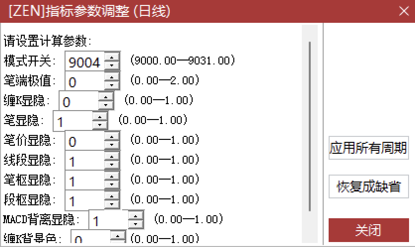

##### 1.3.2.2 信号代码含义

公式中各信号的含义如下：

**笔信号**：

| 信号代码 | 含义 |
| --- | --- |
| 1B | 笔一买 |
| 2B | 笔二买 |
| 3B | 笔三买 |
| 23B | 笔二三买合并 |
| 1S | 笔一卖 |
| 2S | 笔二卖 |
| 3S | 笔三卖 |
| 23S | 笔二三卖合并 |
| 底背驰(弱/强) | 笔底背驰信号 |
| 顶背驰(弱/强) | 笔顶背驰信号 |
| 盘整背驰(弱/强) | 笔盘整背驰信号 |

**线段信号**：

| 信号代码 | 含义 |
| --- | --- |
| 1B-XD | 线段一买 |
| 2B-XD | 线段二买 |
| 3B-XD | 线段三买 |
| 23B-XD | 线段二三买合并 |
| 1S-XD | 线段一卖 |
| 2S-XD | 线段二卖 |
| 3S-XD | 线段三卖 |
| 23S-XD | 线段二三卖合并 |
| 底背驰-XD(弱/强) | 线段底背驰信号 |
| 顶背驰-XD(弱/强) | 线段顶背驰信号 |
| 盘整背驰-XD(弱/强) | 线段盘整背驰信号 |

**MACD背离信号**：

| 信号代码 | 含义 |
| --- | --- |
| MACD底背(弱/强) | MACD 底背离信号 |
| MACD顶背(弱/强) | MACD 顶背离信号 |

> MACD 背离是独立于缠论走势分析的额外信号，不需要缠论中枢/买卖点理论支持，仅依赖 MACD 指标自身的背离判断。即使在公式中不使用缠论走势分析函数，只要拥有走势版授权，MACD 背离信号仍可正常显示。

> MACD 背离没有单独的判据参数：能改的只有指标参数 `MACD背离显隐`（`1`=显示、`0`=隐藏），强弱两档的阈值是内定的，不随 `模式开关`、`推送方式` 或 `笔端极值` 改变。

**背驰强度说明**：

能标出背驰，说明"是不是背驰"的那几条已经同时成立；强度只是在这之后，再看下面两件事各有几件成立：

| 强度 | 通俗含义 | 具体看什么 |
| --- | --- | --- |
| 强 | 两件事都看到了 | ① **推动的力量没跟上**：离开中枢的这一波，黄白线的波峰（波谷）没有超过进入中枢那一波；② **这一波明显更费劲**：离开段的同色柱子合起来不超过进入段的一半，平均到每根 K 线也明显更小 |
| 弱 | 只看到其中一件 | 上面两件事只有一件成立 |

> 分档只问一件事：**上面两件事是不是都成立**（原文说「只要其中一个符合就可以是一个背弛的信号，两个都满足就更标准了」）。强度记的只是**信号出现那一刻的多空力量对比**：强 = 两条力度证据都在，弱 = 只留下一条；它**不代表反转概率**，历史统计里两档之后的走势没有稳定差别，不要拿强弱去预判方向，也不要只挑强档（那会漏掉不少信号）。**真正有意义的是"这里出现了背驰"这件事**：经抽样回测统计，背驰之后价格朝它所指方向走出较大幅度的比例，强档、弱档都显著高于随机进场。回测不代表未来表现，不构成投资建议。**两档都照常出信号**。

> "是不是背驰"本身要四条同时成立才算：① 离开段同色柱子（向上看红柱、向下看绿柱）的面积比进入段缩小（只缩小一点点按抖动处理，不算背驰）；② **黄白线回拉 0 轴到位**——中枢区间内的黄白线要么未破 0 轴且已回到 0 轴附近，要么虽破 0 轴但穿得不深；找不到对应真实中枢时不判本级别背驰；③ **力度方向证据至少一条成立**——黄白线（DIF）峰值同向不创新高/新低，或者"面积不超过进入段的一半（含恰好一半）+ 每根 K 的平均力度也明显减小"同时成立；④ 趋势走势（上涨/下跌）还要求离开段创出新高或新低，盘整走势这一条豁免、只比力度。

> MACD 黄白线的**回拉位置**是背驰成立的共同前提，**峰值**则是两枚方向证据之一。这里的"回到 0 轴附近""破 0 轴但不能太深"是按实际行情设定的经验口径，并非原文给出的精确常数。只量 DIF，不拿 DEA 代替；单看黄白线位置也不能判背驰，仍须与面积和力度方向共同成立。

> **MACD 背离也是"弱/强"两档，但判据与上面那套不同**，它和缠论中枢背驰是两条独立判断：价格创新高（或新低）而 DIF 的波峰（或波谷）没跟上就算背离；强度看 DIF 比前一个极值衰减了多少——不到弱阈值不算背离，达到强阈值标"强"，其余有效背离标"弱"。

> 同样要提醒：两档只反映**当时这一波的力度比上一波衰减了多少**，不代表反转概率，也不是收益或可靠性排序；历史统计不代表未来表现，不构成投资建议。**两档都照常出信号**，只取强档会漏掉不少信号。

> **关于信号落点**：上面这些笔信号和线段信号都只标在**已经确认**的笔 / 线段的末端转折点上——笔信号（不带 `-XD`）落在已确认笔的端点，线段信号（带 `-XD`）落在已确认线段的端点。正在生长的最后一根虚线笔 / 虚线线段，其末端还会随行情继续延伸，因此那一端**不会**出现背驰、一买一卖等标记；等反向的虚线结构出现、前一根转为实线确认之后，信号才会标出来。这样看到的信号基本都不会再消失，只有一种情况例外：紧挨着末端的那几笔，确认之后端点还可能随末端生长再挪（`笔端极值` 取 `1` 或 `2` 时都可能出现，`2` 档最明显），落在它们上面的标记也可能跟着挪；再往前的标记不会被改。

> 两点例外：`MACD背离` 走的是 MACD 指标自身的判断，不依赖笔或线段是否确认，标记位置也就不一定落在笔的端点上；跨级别选用的"端点"信号（信号 `±6`）反过来，看的正是还在生长的最后一根笔 / 线段末端，见下文选股信号说明。

#### 1.3.3 插件选股（极速选股）

使用插件选股功能前，必须先将股票数据下载到本地（具体下载方法见 附录 A.4 通达信盘后数据下载说明），否则无法选出任何股票。

在通达信右上角"公式"菜单下方点击 **"插件选股"**，会弹出选股界面，支持多级别、多信号的组合筛选。选股界面左下角的 **"前复权数据"** 勾选，必须与通达信主界面右上角的**复权**选择保持一致；否则选股用的价格口径与主图不同，结论会对不上（见下图红框）。

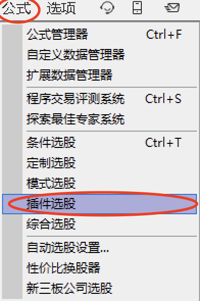

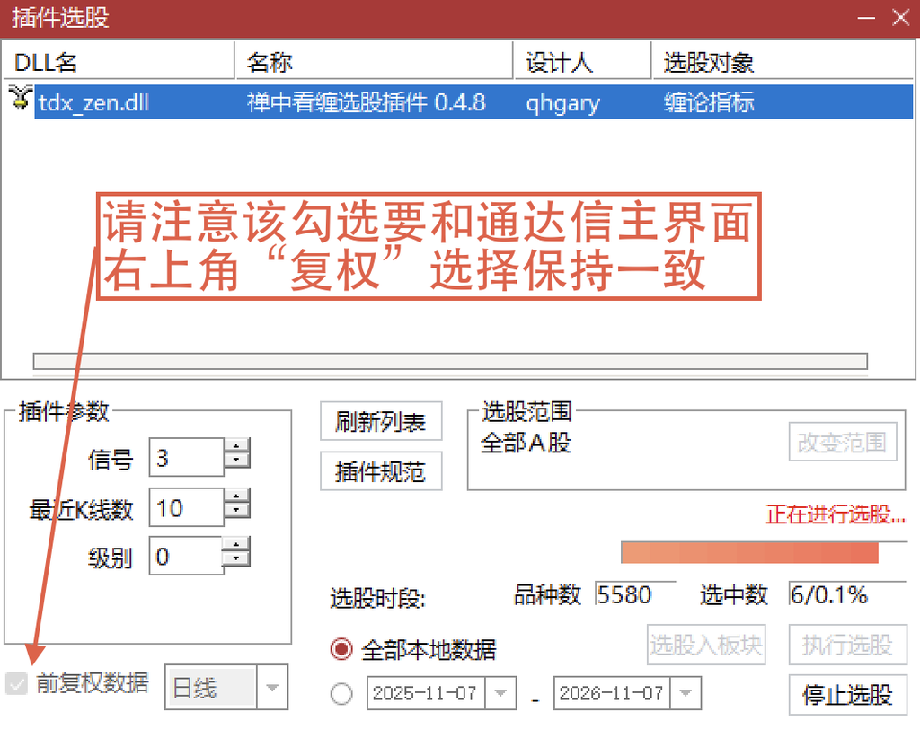

如果本地数据不是最新的，请先把日 K 和 5 分钟数据下载完整再选股，否则"最近K线数量"找到的信号可能超出设定值——插件是把离线数据当作最新数据来搜索的。

> **选股的取数长度：`选股K线数`（写在公式内容里的一个数值，默认 420 根）**：插件选股时，先按这个长度从本地数据取回 K 线再分析。它写在公式内容开头（`选股K线数:=420;`，在 `推送方式` 旁边），**不在指标参数里，一般不需要改**；要改就在公式管理器里打开 ZEN 公式，改这个数字后保存并重新应用公式。改完要回到主图、让它实际画一次（切到带 ZEN 公式的主图看一眼即可），插件才会记住新值并从下一只股票起按新值选股；只改了公式内容、主图没算过的，选股仍按上一次记住的值取数（从未算过主图则是默认 420）。记住的值在通达信重启后仍然有效。

[figure not shown]

> **注意**：插件选股同样需要**选股功能授权**，如果证书缺少选股功能位，即便打开界面执行选股，也无法选出任何股票。

**数据范围选择**：插件选股支持两种数据范围模式，通过界面右侧的**范围**（日期范围）选择控件切换：

| 模式 | 说明 |
| --- | --- |
| **全部** | 不对日期设限，在选股取数长度（`选股K线数`，默认 420 根）内选股，"最近K线数量"的参照点为**最新数据（今天）**（默认模式） |
| **区间** | 仅在用户指定的日期区间内进行选股，取多少根 K 线由起止日期决定（`选股K线数` 在此模式下不生效），"最近K线数量"的参照点为**区间结束日** |

两种模式的参数含义和信号类型完全一致，核心区别在于 **"最近K线数量"的参照点不同**：

- **全部**：信号出现在离今天 N 根 K 线内即命中
- **区间**：信号出现在离**区间结束日** N 根 K 线内才命中（区间起始日之前的数据不参与分析）

> **使用场景示例**：区间选股适合历史回溯——如"查看 2025 年 1 月期间哪些股票出现过三买信号"，只需将区间设为 2025-01-01 ~ 2025-01-31，插件就只分析该月数据，并以 1 月 31 日为参照点在最近 N 根 K 线内搜索信号。

> **注意**：使用区间选股时，先在范围选择控件中设定好日期区间，再执行选股。

##### 1.3.3.1 参数配置表

在插件选股界面中，你可以通过修改参数，灵活指定筛选类型。

[output not shown]

> **±6 端点信号说明**：信号 `+6` 代表向下笔/线段的端点（与买点相关，故用正数），`-6` 代表向上笔/线段的端点（与卖点相关，故用负数）。级别为 `0` 时搜索笔的端点，级别为 `1` 时搜索线段的端点。搜索只看最后一根笔 / 线段，其末端落在最近 N 根 K 线内即命中，更早的端点不参与。

> 这与上文"关于信号落点"的口径正好相反：背驰、一买一卖等标记落在**已经确认**的笔 / 线段末端，±6 落在**还在生长的最后一根**上——也就是图表最右端那段虚线的末端（只有当它刚转为实线、后面还没有新结构时，这一端的状态才是已确认）。

> 理由是两件事要的取舍不同。画图上的标记要稳定，宁可等确认之后再标，也不能标完又被下一根 K 线撤掉；选股要抓的是转折正在酝酿，而这个位置只可能出现在当前正在延伸的那一段上，已确认的端点都属于历史。代价是 ±6 的落点本身还没定型，末端仍会随行情继续延伸或回退。所以 **±6 选出来说明这一处值得关注，不代表此处一定会成为转折点**——要确认，回 K 线图看那根虚线有没有转为实线即可。

> **±7 奔走中枢信号说明**：`+7` 代表**向上**奔走中枢的三买，`-7` 代表**向下**奔走中枢的三卖。奔走中枢不是只有朝上的一种，两个方向完全对称、条件一模一样，只是所有高低点互相调转：
> - **向上奔走（信号 `7`）**：中枢里几个向上的波段，高点一个比一个高，彼此却只擦边重叠，于是整个中枢区间被压得极窄；走势向上离开中枢后，回抽不再回到区间内——三买成立，命中点就是这个三买点。这是"跌不下去、一踩就拉"的逼空式上涨。
> - **向下奔走（信号 `-7`）**：中枢里几个向下的波段，低点一个比一个低，彼此同样只擦边重叠，中枢区间同样极窄；走势向下离开中枢后，反抽不再回到区间内——三卖成立，命中点就是这个三卖点。这是"涨不上去、一碰就跌"的连续杀跌。

> 两个方向的判定都要同时满足六条（缺一条就不算奔走）：
> 1. 中枢本体不超过 5 段——还在围绕中枢来回震荡的算不上，笔数/段数升级后的更长中枢更算不上；
> 2. 进入中枢那一段和离开中枢那一段方向一致，都朝这个买卖点的方向——一进一出方向相反就成了盘整中枢；
> 3. 进入中枢那一段的波动幅度不小于中枢本体那几段的波动范围——进得无力同样成了盘整；
> 4. 中枢区间极窄，它的高度不超过中枢自身那几个波段整体波动范围的一成——进出中枢的两段都不算在内，走得再猛也稀释不了它；
> 5. 离开中枢那一段的极值要继续往外推（向上看高点、向下看低点），且波动幅度不小于中枢区间高度的两倍；
> 6. 中枢里同向波段的极值逐个往外推——向上时看高点，向下时看低点。

> 六条都成立之后，还要该中枢的三买 / 三卖本身已经成立，两者同时命中才算数。所以 `+7` 必然落在三买点、`-7` 必然落在三卖点，不会出现"形态像奔走但还没突破"的情况。

> 级别 `0` 搜笔中枢、`1` 搜线段中枢，笔与线段、向上与向下四种组合同样支持。上面这些比例都只按所选级别自己的波段来量——算笔中枢时不掺入线段的数值。中枢发生扩张或与相邻中枢合并之后，一律按合成后的新中枢重新判定，不再回头看原来的两个。"最近K线数量"对两个方向的含义也一致：就是上面那个三买 / 三卖点落在末尾 N 根 K 线之内。

> 与 `±3` 的区别：`±3` 只看三买 / 三卖这个点，不管中枢长什么样；`±7` 只认上面那种奔走形态，所以命中更少，`+7` 选出来的是"向上离开得干净"的那一批，`-7` 选出来的是"向下离开得干净"的那一批。

> 关于时机：奔走中枢要等离开中枢之后那一笔回抽走完、三买 / 三卖点出现才命中——向上等回抽不破区间上沿，向下等反抽不回区间下沿。刚突破、回抽（反抽）还没走完时选不到，这是形态确认必须付的等待，换来的是选出来的每一处都已经站得住。

> 选股的分析设置与主图一致：模式开关、推送方式、笔端极值、选股取数长度都取你最近一次在主图上使用的设置，主图上改完再执行选股就按新设置计算，不需要重启。如果从未在主图上使用过（例如只用选股），则按默认值计算：`模式开关=9004`、逐根推送、笔端极值无要求（0 档）、选股取数 420 根。这样同一只股票在选股与主图上看到的笔、线段、中枢与信号口径相同。其中 `选股K线数` 与前三项不同：它写在公式内容里（不在指标参数里），改完要保存并重新应用公式、让主图算一次，选股才按新值取数。

##### 1.3.3.2 跨级别组合选股（多周期共振）

本插件支持极致灵活的跨级别选股，核心思路是：**先用大级别条件筛选出股票存入临时板块，再以此为范围叠加小级别条件进行二次筛选**——两个周期的信号交集即为多周期共振的精确结果（例如：日线底背驰 + 30分钟二买）。

**操作流程**：

1. **第一步（大级别筛选，建立临时板块）**：
   - 将周期选择为较大的级别（如 **"日线"**）。
   - 设置参数：选择你需要的大级别信号（如信号 `4`=底背驰，级别 `0`=笔），最近K线数量填 `10`。
   - 执行选股，完成后将结果**全选 -> 右键加入到板块 -> 新建自定义板块**（例如命名为"日线底背驰"）。
2. **第二步（小级别共振，范围限定）**：
   - 再次打开插件选股，将周期切换为较小的级别（如 **"30分钟"**）。
   - **关键**：将界面右侧的**选股范围**（股票池）更改为刚才建立的**临时板块**（如"日线底背驰"）。
   - 设置小级别参数：如信号 `2`（二买），最近K线数量填 `15`（小周期走得快，可适当放宽）。
   - 执行选股——最终结果即为同时满足**大级别条件 AND 小级别条件**的股票。

> **提示**：此方法也可反向使用（小级别初筛 + 大级别精选），或叠加更多层级逐级收敛。临时板块可反复复用——只要其中的股票数据未变，随时可以不同的参数对同一批股票做二次筛选。

⬆ 回到目录

### 1.4 关于绘图公式

> 普通用户可以忽略此章节，直接使用默认公式即可。以下内容面向想高度定制绘图效果的高阶用户。

通达信主图公式设有防误改密码 `33333333`。设置密码的目的仅为防止用户误操作修改公式导致显示异常，并非为了保密。

在通达信的公式管理器中打开 ZEN 主图公式时，输入上述密码即可查看完整公式内容。公式里的绘制开关取值已经全部做成指标参数，高阶用户无需改动公式内容，在指标参数里改对应取值即可控制绘制段的显隐（显隐类开关 `1`=绘制、`0`=隐藏）或配色（`缠K背景色` `0`=黑底、`1`=白底），详见 1.4.2 常用公式配置组合。

**注意事项：**

- 该公式依赖插件 DLL 提供的计算结果，必须与通达信插件配合使用。在未安装插件的环境中——包括未安装插件的通达信、以及安卓版通达信——公式均无法正常工作。
- 关于公式本身的编写细节与自定义方法，请自行研究，或在本项目的 QQ 交流群内提问。

#### 1.4.1 funcid 功能索引

以下是通达信公式中通过 `TDXDLL2(funcid, H, C, L)` 调用的各功能编号及其用途，供高级用户自定义公式时参考：

| funcid | 功能 | 授权 | 说明 |
| --- | --- | --- | --- |
| 100 | 触发分析 | 基础版 | 仅触发一次缠论分析计算，不输出数据 |
| 105 | 合并K线低点 | 基础版 | 输出合并K线的低点值：正数=独立合并K，负数=被合并的原始K。低点为负（前复权）时正负号已被价格本身占用，无法再区分独立性，一律按"被合并"输出；负价格行情请改用 107 判独立性、108 取低点 |
| 106 | 合并K线高点 | 基础版 | 输出合并K线的高点值，与105/108配对即可绘制缠论合并K线 |
| 107 | 合并K线独立性标记 | 基础版 | 1=独立合并K，-1=被合并的原始K，与价格正负无关 |
| 108 | 合并K线低点（原始值） | 基础版 | 输出真实的合并低点，负价格原样输出、不带独立性标记，需与107搭配使用 |
| 110 | 笔连线 | 基础版 | 输出笔的连线价格 |
| 120 | 线段连线 | 基础版 | 输出线段的连线价格 |
| 130 | 笔待定状态 | 基础版 | 输出笔的待定状态标记（0=确认, 0.5=过渡, 1=待定） |
| 131 | 线段待定状态 | 基础版 | 输出线段的待定状态标记（0=确认, 0.5=过渡, 1=待定） |
| 210 | 笔中枢 ZG | 中枢版 | 输出笔中枢上沿 |
| 211 | 笔中枢 ZD | 中枢版 | 输出笔中枢下沿 |
| 220 | 线段中枢 ZG | 中枢版 | 输出线段中枢上沿 |
| 221 | 线段中枢 ZD | 中枢版 | 输出线段中枢下沿 |
| 218 | 笔买卖点/背驰 | 走势版 | 输出笔的买卖点和背驰信号 |
| 228 | 线段买卖点/背驰 | 走势版 | 输出线段的买卖点和背驰信号 |
| 301 | MACD背离 | 走势版 | 输出 MACD 顶底背离信号（独立于缠论分析）。数值 `±11`=弱、`±13`=强，正数为底背离、负数为顶背离 |
| 800 | 切换逐根推送 | 基础版 | 切换为逐根推送模式（默认），不输出数据 |
| 801 | 切换整体推送 | 基础版 | 切换为整体推送模式，不输出数据 |
| 802 | 笔端极值=0 | 基础版 | 切换为"笔的起点和终点都不要求是极值"（默认），不输出数据 |
| 803 | 笔端极值=1 | 基础版 | 切换为"只要求笔的终点是极值"，不输出数据 |
| 804 | 笔端极值=2 | 基础版 | 切换为"笔的起点和终点都要求是笔内极值"，不输出数据 |
| 805 | 选股K线数 | 基础版 | 读取第一个数据参数作为选股请求的K线根数（公式里传 `选股K线数` 这个数值，默认 420，范围 120~2000），不输出数据 |
| 9000~9031 | 配置型 funcid | 基础版 | 通过 funcid 值直接设置分析模式，仅设置参数不输出数据 |

> funcid 9000~9031 与 1.3.1 模式开关 一节的编码完全对应。

> `800~805` 是切换设置用的入口，用法与 `9xxx` 一样写在公式里（第一个参数就是 funcid 数字），同样只把设置记下来并立即重新计算、不输出任何数值。`9xxx` 的编号本身就是模式值，`800~805` 则是固定用途的入口，其中 `805` 还要从第一个数据参数读取数值。公式中 `TDXDLL2(802+笔端极值,H,C,L)` 这一行就是按这个设置的取值 `0`/`1`/`2` 依次调用 `802`/`803`/`804`，`TDXDLL2(IF(推送方式<0.5,801,800),H,C,L)` 按推送方式在 `800`/`801` 之间二选一。`805` 是唯一带数值的入口：写成 `TDXDLL2(805,选股K线数,H,C)`，其中 `选股K线数` 是公式内容开头写的一个数值（默认 420），第一个数据参数的值就是选股取数长度，超出 `120~2000` 时按边界值处理并记住，选股从下一只股票起按记住的值取数。

> `800~805` 只设置参数、不产出数据，**任何授权等级下都可以调用**，所以授权一栏与基础版功能一样记为「基础版」。

#### 1.4.2 常用公式配置组合

根据需要，可以通过修改指标参数里的绘制开关，自由组合要显示的内容或配色（下面列出的开关全部是指标参数，改动取值不需要碰公式内容，Alt+T 或主图右键调出参数设置即可）：

**完整内容（默认）**： 显示笔、线段、中枢、买卖点、背驰、MACD背离等全部内容；K线本体默认显示通达信原始K，想看已完成包含关系合并的缠论口径K线，把指标参数 `缠K显隐` 改为 `1`。

**只看笔**：`笔显隐` 保持 `1`，把 `线段显隐`、`笔枢显隐`、`段枢显隐`、`MACD背离显隐` 全部改为 `0`，图上就只剩笔的连线（确认笔实线、待定笔虚线）；还想在每个笔端点看到价格，再把 `笔价显隐` 改为 `1`。

**只看线段**：`线段显隐` 保持 `1`、`段枢显隐` 保持 `1`（这个开关同时负责线段中枢及其买卖点与背驰），把 `笔显隐`、`笔价显隐`、`笔枢显隐`、`MACD背离显隐` 改为 `0`；连线段中枢也不想显示的话，把 `段枢显隐` 一并改为 `0`，剩下的就只有线段本身。

> 上面三种组合都只动绘制类开关，**不改变任何分析结果**——线段的确认口径、中枢的级别、买卖点的判定只由 `模式开关`、`推送方式` 与 `笔端极值` 决定，绘制开关只决定"算出来之后画不画"。所以同一只股票在"只看笔"和"完整内容"下，笔的位置完全一样。

**关于缠论合并K线**：由于通达信的限制，无法让其不绘制原始K，因此要显示缠论合并K线时，公式先用与图表背景同色的粗柱覆盖原生K线，再叠加缠论合并K线（独立合并K用实线，被合并原始K用虚线）。该行为由指标参数 `缠K显隐` 控制：`0`=直接显示通达信原始K线（默认），`1`=绘制缠论合并K线，无需改动公式内容。注意：`缠K显隐` 只是显示开关，不改变任何分析结果；笔的落点口径见上文 1.3.2.1 指标参数设置「关于笔的落点」，两种显示下落点完全一致。

**覆盖柱的背景色**：公式默认按通达信的黑色背景配色。其中和图表背景强相关的两处——覆盖原生K线的那根粗柱、缠论合并K线本体的取色——由开关 `缠K背景色` 一起切换：`0`=黑色背景（通达信默认），`1`=白色背景。这个参数只让上述两处的配色与图表背景保持一致，**不会改变通达信主图本身的背景色**。粗柱必须和你看到的图表背景一个颜色，否则原生K线会露出一圈残留边线。这两处都只在指标参数 `缠K显隐=1`（绘制缠论合并K线）时才画，默认显示原始K线时改 `缠K背景色` 看不出差别。切换图表背景后，把指标参数 `缠K背景色` 改成对应值即可，不需要改动公式内容。除黑白以外的背景色，需按公式为覆盖柱与合并K柱两组各补一条 `STICKLINE`（复制对应的现成语句、改掉判断值和颜色后缀），详见公式第 5 节的说明。

> `缠K背景色` 只负责上面这两处。虚线框、实体框、各类文字与图标颜色仍保持黑色背景下的取值，白色背景下若觉得偏淡或看不清，请在公式里把对应行的颜色后缀改成自己习惯的颜色（每段绘制的颜色都写在该行末尾，形如 `COLORXXXX`），公式本身不会替你猜。

**关于笔端点价格**：默认隐藏中，如需显示，把指标参数 `笔价显隐` 改为 `1` 即可在每个笔的端点显示价格（`1`=显示，`0`=隐藏）。

**其余部分如果不要某段显示，直接在指标参数里把对应开关改为 `0` 即可**。绘制类共 7 个开关（6 个显隐开关 + `缠K背景色`），每个独立控制一段绘制或一处配色，互不影响。下表把 10 个指标参数一次列全：前 3 个是 `模式开关`、`笔端极值`、`缠K显隐`（前两个改变分析结果，`缠K显隐` 只改显示），后 7 个是绘制类，默认值可在一处查全。绘制类这 7 个开关现已全部做成指标参数，直接在参数里改取值即可；`推送方式` 与 `选股K线数`（只影响选股取数）仍写在公式内容开头：

| 开关 | 控制内容 | 默认值 | 修改位置 |
| --- | --- | --- | --- |
| `模式开关` | 分析模式组合：`9000` 加上各开关对应的数，决定笔、线段、中枢等的取值（各开关含义见 1.3.1 模式开关）；**改变分析结果** | 9004 | **指标参数**（Alt+T） |
| `笔端极值` | 笔的端点是否要求是笔内极值：`0`=都不要求、`1`=只要求终点、`2`=起点和终点都要求；**改变分析结果**，三档取舍见 1.3.2.1 指标参数设置 | 0 | **指标参数**（Alt+T） |
| `缠K显隐` | 缠论合并K线重绘（`0`=直接显示通达信原始K线，`1`=先用与背景同色的粗柱覆盖原生K线再叠加合并K） | 0 | **指标参数**（Alt+T） |
| `笔显隐` | 笔（确认笔实线 + 待定笔虚线；`0`=不绘制） | 1 | **指标参数**（Alt+T） |
| `笔价显隐` | 笔端点价格（每个笔端点标注价格数字，默认隐藏；`1`=显示） | 0 | **指标参数**（Alt+T） |
| `线段显隐` | 线段（确认线段实线 + 待定线段虚线；`0`=不绘制） | 1 | **指标参数**（Alt+T） |
| `笔枢显隐` | 笔中枢及其买卖点/背驰（`0`=全部隐藏） | 1 | **指标参数**（Alt+T） |
| `段枢显隐` | 线段中枢及其买卖点/背驰（`0`=全部隐藏） | 1 | **指标参数**（Alt+T） |
| `MACD背离显隐` | MACD 底背/顶背（独立于缠论，仅供参考，勿与缠论背驰混淆；`0`=不绘制） | 1 | **指标参数**（Alt+T） |
| `缠K背景色` | 缠K覆盖柱与合并K柱配色（排在参数列表最后；`0`=黑底、`1`=白底，须与图表背景一致，不改变主图背景色，也不影响分析结果） | 0 | **指标参数**（Alt+T） |

> 上表 10 个开关全部是指标参数，在通达信的指标参数设置里改取值即可（Alt+T 或主图右键调出），切换后立即生效、不需要改动公式内容，参数含义与取值范围见 1.3.2.1 指标参数设置。将某个显隐开关改为 `0`，公式就不再绘制那一段内容。注意：笔中枢开关 `笔枢显隐` 同时控制笔中枢绘制及其买卖点（1B/2B/3B/23B、1S/2S/3S/23S）、趋势背驰与盘整背驰；线段中枢开关 `段枢显隐` 同理控制线段中枢、线段买卖点（-XD 系列）与线段背驰。

#### 1.4.3 关于缠论分析的 K 线数量

图表分析所使用的 K 线数量与通达信"系统设置 > 分析设置"中的设置一致，默认加载中间档 420 根。

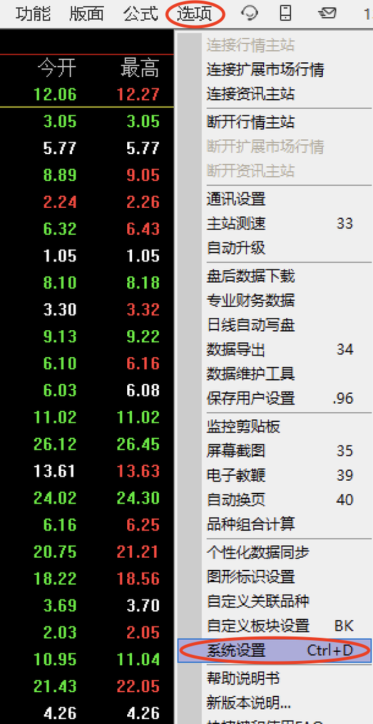

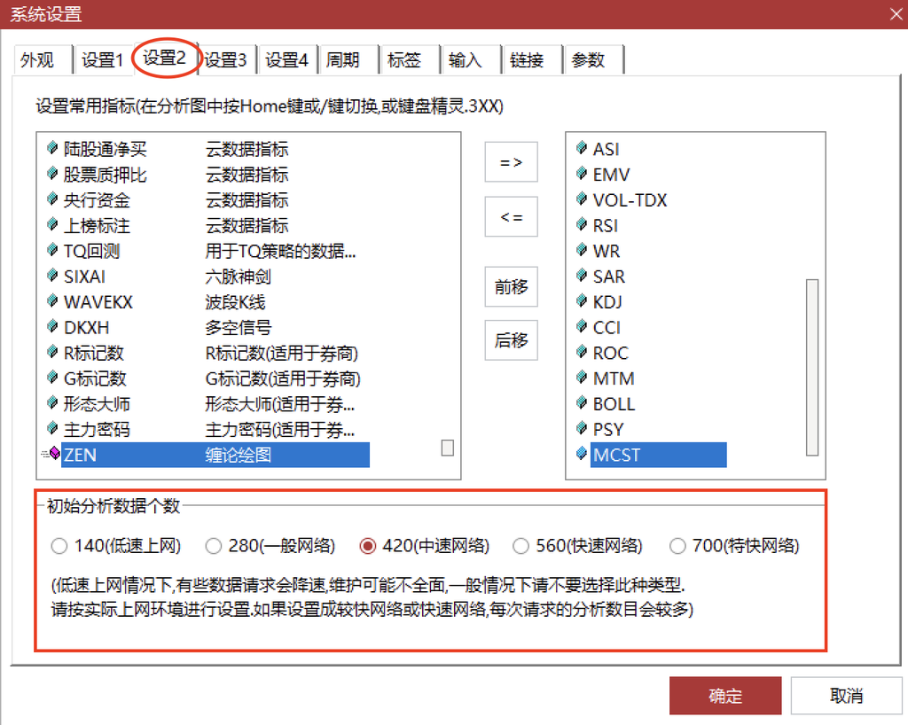

⬆ 回到目录

### 1.5 禅中看缠回测工具

回测工具是通达信插件版的附带工具，用于深入学习缠论分析的全过程。通过加载通达信导出的 txt 格式 K 线数据，可以逐根回放缠论分析的每一步，帮助理解笔、线段、中枢、买卖点等结构是如何随行情演变逐步形成的。

#### 1.5.1 适用场景

- 想直观理解不同模式开关取值对分析结果的影响
- 想观察缠论结构（笔、线段、中枢、买卖点）的动态形成过程
- 盘后复盘，对照历史行情学习缠论理论

#### 1.5.2 授权与试用

回测工具与通达信插件版**共享授权**：机器码相同，试用期与协议同意状态互通——任一侧试用期到期，另一侧同样无法试用。正式授权时，需将同一份 `zen_license.key` 授权文件分别放到回测工具目录和通达信 DLL 所在目录（见 1.2.2 完成授权），一份授权两处通用，无需单独购买。（以上指 Windows 版回测工具；macOS 版回测工具使用独立机器码与授权，如需使用请联系作者单独获取。）

各等级开放的内容见 附录 A.2 授权等级。

#### 1.5.3 使用方法

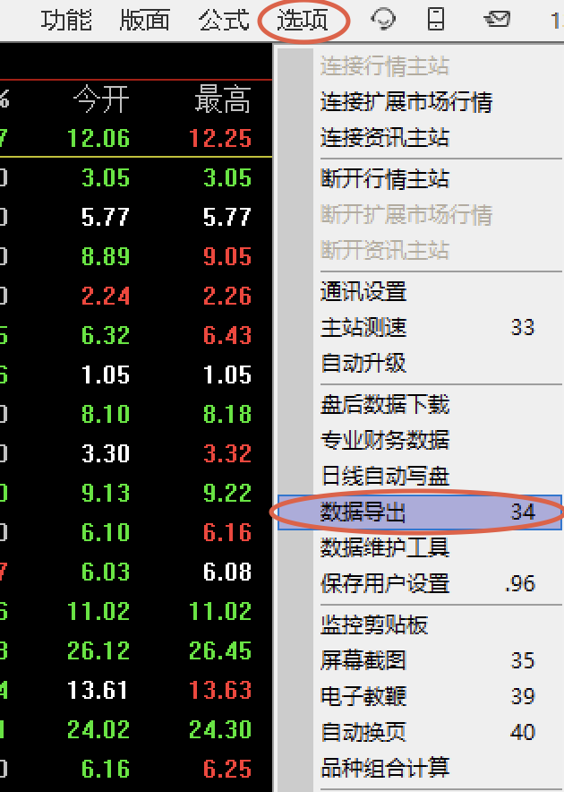

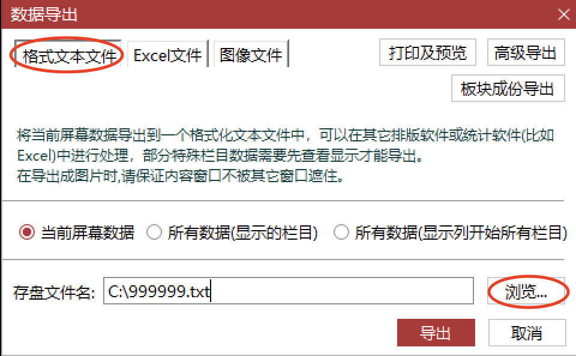

2. 打开回测工具，点击左上角"📂 加载数据"，选择导出的 txt 文件。
3. 加载成功后，顶栏会显示当前文件名与股票信息，底部播放控制栏实时显示当前回放步数（a/b）；显示十字线后还会同步显示十字线所在 K 线的日期与价格。
4. 使用底部播放控制栏进行回放：
   - **⏮ / ⏭**：跳到起点 / 终点
   - **◀◀ / ▶▶**：单步后退 / 前进（也可用键盘 ← →）
   - **▶ 播放**：自动逐根播放（也可用空格键）
   - **速度选择**：可选 0.5x / 1x / 2x / 4x 倍速播放（默认 1x）
   - **数据时间范围**：拖动滑块设定回放的起止范围
   - **十字线**：双击图表显示/隐藏十字线（双击命中笔或线段时优先显示其编号，不切换十字线）。十字线显示后跟随鼠标移动，顶栏同步显示十字线所在 K 线的日期与价格；十字线不会越过最新已回放的 K 线
   - **缩放**：点击 − / + 按钮或键盘 ↑↓ / +−（或 **Ctrl+滚轮**）调整 K 线宽度（默认显示较密集的 K 线，可缩小至更宽视角或放大至更细观察）。未显示十字线时，缩放以当前回放步所在 K 线为中心（其屏幕位置保持不动）；显示十字线后，每级缩放实时将十字线所在 K 线校准至可视区域正中心
   - **平移**：在图表区域拖拽鼠标可左右平移视图；滚轮 / 触控板横滑按步进平移。十字线显示期间拖拽平移暂停（鼠标移动只更新十字线位置）
5. 通过顶部图层面板可勾选显示/隐藏各层结构：缠K、分型、笔、笔端点价格、笔中枢、线段、线段中枢、MACD背离、缠论BS点、中枢背驰。其中分型、笔端点价格默认不显示，其余图层默认开启。
6. 交易模拟：底部交易栏支持按资金比例（25% / 50% / 100%）买入和卖出，可清仓或重置交易记录，实时显示投入仓位、当前收益和总收益。点击图表中的买卖标记会弹出确认菜单，点击"删除此交易"后才会真正删除。双击图表中的笔或线段可显示其编号（从 0 开始），点击旁边区域关闭。

#### 1.5.4 分析参数

回测工具中的分析开关（缺口成笔、新笔成笔、中枢拓展、中枢扩张、允许跨界）与通达信插件版完全一致，含义与推荐设置请参阅 附录 A.1 模式开关详解，完整组合表请参阅 1.3.1.1 完整组合表。顶部有"通达信MODE值"输入框（回测工具的界面文案仍用这个写法），可直接输入模式开关数值（如 9004），也可以点击下方开关按钮自动换算，方便与通达信中的参数设置对照。

回测工具同样提供 `笔端极值` 循环按钮（默认"无要求"），点一下按 **无要求 → 仅终点 → 起+终** 循环切换，切换后立即按新口径重新分析，设置自动保存。它对应通达信指标参数 `笔端极值` 的 `0`/`1`/`2` 三档，含义与取舍见 1.3.2.1 指标参数设置 的「笔端极值说明」。

笔的端点取价固定为缠论合并K线的极值，不提供切换；落点只顺方向前进、不会后退。图层面板的"缠K"勾选框只切换合并K线与原始K线的显示，不改变分析结果。上述设置自动保存，下次启动恢复。

#### 1.5.5 逐根推送与整体推送

回测工具底部提供"逐根推送"和"整体推送"切换，对应通达信版中的 **推送方式** 设置。两种模式的详细说明请参阅 1.3.2.1 指标参数设置 中的推送方式说明。

> **逐根推送**适合观察每根 K 线加入后缠论结构的动态变化过程，是回测的推荐模式；**整体推送**展示按全部数据重算后的最终结果，适合快速查看最终状态。

#### 1.5.6 交易模拟（买卖回测）

回测工具内置交易模拟系统，可结合缠论买卖点信号进行模拟交易，帮助验证交易策略的盈亏表现。

**基本机制**：

- 交易模拟以**比例口径**计量（界面不显示具体金额），交易以当前回放步的 K 线收盘价成交。
- 仓位按**买入/卖出百分比的简单加减**计量（如买 25% 两次即为 50%），总仓位上限为 100%。

**买入操作**：

底部交易栏提供三个买入按钮：

| 按钮 | 说明 |
| --- | --- |
| 买入 25% | 投入总资金的 25% 买入 |
| 买入 50% | 投入总资金的 50% 买入 |
| 买入 100% | 投入全部资金买入 |

买入时系统自动计算可买股数（取整），扣除可用资金，累计持仓成本和均价。当总仓位 + 本次买入比例超过 100% 或可用资金不足时，对应按钮自动禁用。

**卖出操作**：

| 按钮 | 说明 |
| --- | --- |
| 卖出 25% | 减仓总资金的 25%（按成本计量） |
| 卖出 50% | 减仓总资金的 50%（按成本计量） |
| 卖出 100% | 清空全部持仓 |

卖出时按持仓均价计算减仓股数，卖出收入计入可用资金，盈亏计入已实现盈亏。当目标减仓比例超过当前仓位时，对应按钮自动禁用。

**其他操作**：

| 按钮 | 说明 |
| --- | --- |
| 清仓 | 以当前价格全部卖出持仓，相当于卖出 100% |
| 重置 | 清空所有交易记录，仓位与收益统计全部归零 |

**键盘快捷键**：

除鼠标点击外，交易操作还支持键盘快捷键：

| 快捷键 | 操作 |
| --- | --- |
| **1 / 2 / 3** | 买入 25% / 50% / 100% |
| **Q / W / E** | 卖出 25% / 50% / 100% |

**实时统计信息**：

交易栏右侧实时显示三项指标：

| 指标 | 说明 |
| --- | --- |
| 投入 | 买入/卖出百分比的简单加减（如买 25% 两次即 50%，不随价格波动） |
| 当前收益 | 当前持仓的浮动盈亏占持仓成本的比例（随当前价格实时变化，清仓后归零） |
| 总收益 | 所有已平仓交易的累计盈亏占初始资金的比例（清仓不会清零，保留全部已实现收益） |

盈亏为正时显示为红色，为负时显示为绿色。

**交易标记**：

每笔交易在 K 线图上以标记显示：买入为红色 ▲（K 线下方），卖出为绿色 ▼（K 线上方）。**点击图表中的买卖标记会弹出确认菜单，点击"删除此交易"后才会真正删除**，系统会自动重新计算持仓和盈亏。

**笔/线段编号查看**：

**双击图表中的笔或线段可显示其编号**（从 0 开始编号，第一笔为笔0，第一个线段为线段0），与左下角 `a/b` 进度指示的编号方式一致。点击旁边区域即可关闭编号显示。

⬆ 回到目录

## 第二部分：桌面版

### 2.1 安装与部署

1. 从发布页面下载压缩包并解压。
2. 运行 `zen_desktop` 可执行文件。
3. 首次运行自动生成 `.zen_settings.json` 配置文件（隐藏文件），用于存储数据源和缠论按钮状态，下次启动自动恢复。

### 2.2 首次运行与授权

首次启动会弹出**许可证协议**窗口，同一版协议正文**只展示一次**，阅读后点击"同意"继续。只有软件升级且新版改动过协议正文时才会再次弹窗征求同意；协议正文未变的升级不会重复弹出。

#### 2.2.1 获取机器码

点击界面左上角 **"授权"** 按钮，查看机器码（格式 `zen-xxxxxxxx-xxxxxxxx`），发送给作者获取授权。

#### 2.2.2 完成授权

两种授权方式，任选其一：

1. **文件方式**：把 `zen_license.key` 授权文件放到应用程序**同一目录**下（与 `zen_desktop` 可执行文件放在一起，Windows 下即 `zen_desktop.exe`）。
2. **粘贴方式**：点击界面左上角 **"授权"** 按钮，将从作者处获取的授权内容粘贴到弹出的输入框中，点击"确认"即可。

> 无授权时，可无限制使用 **3 天试用期**。

各等级开放的内容见 附录 A.2 授权等级。

#### 2.2.3 试用期说明

- 试用期不需要任何授权文件，直接运行即可使用
- 试用期结束后，需要获取正式授权文件才能继续使用
- 试用期需联网验证，离线无法激活试用
- 联网是使用前提，正式授权（含永久授权）同样需联网校时；断网期间无法分析，恢复联网后自动恢复

### 2.3 界面说明

#### 2.3.1 开关说明

[output not shown]

> **默认状态**：首次运行（还没有保存过设置）时，逐根推送；缺口成笔、新笔成笔、中枢扩张、允许跨界均为关闭；中枢拓展、笔、线段、笔中枢、MACD背离为开启；线段中枢、笔端点价格与缠K为关闭；笔端极值为无要求（0 档）。此后每次启动恢复上次保存的状态。授权校验通过、进入主界面后自动开始分析，不需要手动开启。

> **五个分析开关都是"各家做法不同"的地方，没有对错**：开与不开只改变图上笔和中枢的粗细程度。笔端极值决定笔的起点和终点要不要都落在真实高低点上；缺口成笔和新笔成笔是两种放宽成笔条件的方式，前者照顾跳空多的行情（日线以上尤其常见），后者照顾 K 线密集、包含关系多的行情，两者互不影响、满足其一即可成笔；中枢拓展和中枢扩张决定中枢能延续多长、要不要合并成大中枢。拿不定主意就全部保持默认。两种成笔怎么放宽都不会绕过"顶分型与底分型不能共用 K 线"这一条。三个中枢开关里只有「允许跨界」是笔中枢专属，拓展与扩张是笔、线段两层共用一个开关，只是线段数目少，通常看不出差别（见 1.3.1）。

> **配置持久化**：所有开关和勾选框的状态会自动保存到 `.zen_settings.json` 文件中，关闭程序后下次启动会自动恢复上次的状态，无需每次重新设置。

#### 2.3.2 周期切换与自选股

**周期切换**：

- 主图上方为周期标签：**5分钟 / 30分钟 / 日线 / 周线 / 月线**，点击即可切换。
- 各周期的缩放状态**独立记忆**，在一个周期内缩放不影响其他周期的显示。

**自选股**：

- 在左侧面板底部输入框输入股票代码或拼音首字母（如 `600000` 或 `zgpa`），点击"新增"加入自选。
- 选中列表中的股票后点击"删除"即可移除。
- 点击自选报价列表中的某一行即可切换显示该股票；也可以用键盘 **↑ / ↓** 在列表中快速切换股票。

**其他按钮**：

| 按钮 | 说明 |
| --- | --- |
| **竞价** | 显示/隐藏分时图的盘口竞价数据 |
| **画线** | 打开图表画线工具栏（工具栏上自带关闭按钮，点它关闭；主界面上的这个按钮只负责打开） |

#### 2.3.3 K线图操作

**十字线模式**：

- **进入**：在主图 K 线区域**双击**，或按键盘 **← / →** 方向键，即可显示十字线。
- **移动**：十字线显示时跟随鼠标移动；按 ← / → 可逐根移动光标。
- **退出**：再次**双击**或按 **ESC** 键。

**视图操作**：

| 操作 | 方法 |
| --- | --- |
| 缩放 | 键盘 ↑ / ↓ 键微调缩放（细腻平滑），或鼠标滚轮（上滚放大，下滚缩小）。缩放以视图**最右端（最新 K 线）为中心**，左侧内容随之增减 |
| 定点居中缩放 | 双击进入十字线模式，将十字光标移至目标位置后按 ↑ / ↓（或 **Ctrl+滚轮**）缩放，视图边缩放边实时将十字光标所在位置保持在可视区域正中心 |
| 平移 | 按住鼠标左键左右拖动。十字线显示与否不影响拖拽平移，十字线在平移过程中保持显示 |
| 触控板 | 双指横移平移视图，双指捏合缩放 |

**加载更多历史K线**：

笔/线段以**虚线**绘制时表示处于**待定状态**：方向已经确定，但终点分型尚未确认，落点还没有定下来。为提高走势识别的敏感度，无须等到终点分型完全形成——只要这一笔已经可以确定形成（满足成笔所需的独立K线数量与区间要求），即使终点分型还没有走出来，也会先以虚线画出，落点取到端点那根缠论合并K线的极值上，使虚线端点始终连在真实K线的影线上。此后落点只顺方向前进、不会后退。待终点分型确认后，虚线转为实线。显示口径与通达信插件版一致。

### 2.4 数据源

禅中看缠 桌面版内置行情数据源，安装后即可取数，无需任何配置。

> 行情数据来自第三方公开数据源，用户需自行承担使用责任，与本软件及作者无任何关联。

⬆ 回到目录

## 第三部分：安卓版

### 3.1 安装与部署

1. 从发布页面下载 APK 安装包
2. 在安卓设备上安装（需要先开启"允许安装未知来源应用"）
   - 设置 → 安全 → 允许安装未知来源应用
3. 首次运行自动初始化

### 3.2 首次运行与授权

首次启动会弹出**许可证协议**窗口，点击"同意"继续。同一版协议正文只展示一次；只有软件升级且新版改动过协议正文时才会再次弹窗征求同意。

#### 3.2.1 获取机器码与完成授权

授权流程与桌面版一致：点击界面 **"授权"** 按钮查看机器码，发送给作者获取授权。推荐用**粘贴方式**激活：将从作者处获取的授权内容粘贴到授权输入框中，点击"确认"即可（安卓应用的文件目录普通文件管理器通常看不到，把 `zen_license.key` 直接拷进去并不方便，因此以粘贴方式为主）。详见 2.2 首次运行与授权。

> **注意**：安卓版不支持免授权的 3 天试用，必须使用授权文件激活。联网要求与其他成品一致——正式授权（含永久授权）也需联网校时，断网期间无法进行缠论分析，恢复联网后自动恢复。

各等级开放的内容见 附录 A.2 授权等级。

### 3.3 界面说明

分析开关及含义与桌面版完全一致，详见 2.3.1 开关说明 和 附录 A.1 模式开关详解。与桌面版的差异：

- 无 **"画线"** 工具栏按钮（安卓上不提供桌面版那套画线工具栏），保留 **"竞价"** 按钮
- 周期标签为缩写形式：**5分 / 30分 / 日 / 周 / 月**
- 报价列表为安卓适配布局
- 开关状态通过本地存储自动保存，下次启动恢复

#### 3.3.1 K线图操作

**十字线模式**：

- **进入 / 退出**：在 K 线图上**双击**切换十字线显示（双击也可最大化/还原附图指标窗口，与桌面版一致）。
- **长按**：按住约半秒（手指保持不动）会出现跟随手指的十字光标刻度（时间/价格标签），松开手指后消失；长按**不会**显示十字线。

**手势操作**：

| 操作 | 方法 |
| --- | --- |
| 平移 | 单指左右滑动。十字线显示与否不影响平移，十字线在滑动过程中保持显示 |
| 缩放 | 双指捏合。默认以视图**最右端（最新 K 线）为中心**缩放 |
| 定点居中缩放 | 双击显示十字线后进行双指捏合缩放，视图在每级缩放过程中实时将当前十字线校准至可视区域正中心，连续缩放丝滑无顿挫 |
| 加载更多 | 单指滑动到数据尽头后继续向右滑动，自动加载更多历史K线 |

加载数量、续拖定位、待定笔/线段虚线显示等机制与桌面版一致，详见 2.3.3 K线图操作。

⬆ 回到目录

## 附录

### 附录 A.1 模式开关详解

五个开关分别对应缠论原文没有写死、各家做法不同的五处，开与不开都没有对错，只改变图上笔和中枢的粗细程度；笔中枢与线段中枢的关系见 1.3.1 的说明。每个开关具体是什么、打开后图面怎么变，见 2.3.1 开关说明；数字组合见 1.3.1.1 完整组合表。

| 开关 | 管什么 | 推荐 | 理由 |
| --- | --- | --- | --- |
| **缺口成笔** | 跳空缺口算不算一笔 | 按需 | 日线以上跳空多、觉得漏笔就开；只看分钟级别可以不开 |
| **新笔成笔** | 一笔至少要几根 K 线：老笔数独立 K 线，新笔数两个极点之间的原始 K 线 | 按需 | K 线密集、笔太少时开；要最严格的老笔口径就不开 |
| **中枢拓展** | 回到中枢算不算中枢的一部分 | 推荐开启 | 中枢延续更贴近大多数人的看图习惯，中枢不会频繁断开 |
| **中枢扩张** | 相邻中枢是否直接合成大中枢 | 按需 | 想在本周期看大结构就开；想看笔中枢的细节就关（默认关），大中枢到高一级别看 |
| **允许跨界** | 笔中枢能否跨线段延伸 | 推荐关闭 | 不跨线段时结构更细、信号更多，便于本级别操作 |

> 拿不定主意时全部保持默认（9004，只开拓展），已经能覆盖大多数情况。注意两个联动：打开中枢扩张会自动打开中枢拓展；关掉中枢拓展会自动关掉中枢扩张（反过来不成立）。

### 附录 A.2 授权等级

四个等级逐级叠加，高等级包含低等级的全部功能。四个成品（通达信 DLL 插件版、回测工具、桌面版、安卓版）用同一套等级：

| 等级 | 多出的内容 |
| --- | --- |
| **基础版** | 笔、线段、缠K（合并K线）、笔/线段待定状态 |
| **中枢版** | + 笔中枢、线段中枢 |
| **走势版** | + 买卖点（1B/2B/3B/23B、1S/2S/3S/23S）、背驰、MACD背离 |
| **选股版**（全功能版） | + 极速选股（仅通达信 DLL 插件版） |

- 等级只决定**哪些内容出现**：票面等级不含的部分不会显示，其余照常，不报错也不弹窗；需要更多内容时联系作者换发对应等级的授权。
- 其余三个成品没有选股功能，对它们来说选股版与走势版看到的内容一致。
- 通达信 DLL 插件版按公式功能号划分等级，逐号对照见 1.4.1 funcid 功能索引 的"授权"列。
- 试用期内上述内容全部开放，与最高等级（全功能版）看到的一致；选股功能仅通达信 DLL 插件版提供，其余三个成品没有选股功能，对它们来说试用期看到的即是走势版内容；安卓版不支持免授权试用，须凭授权文件使用。

试用期结束后需正式授权文件（联系作者获取）方能继续使用。请通过作者提供的联系方式附上机器码。

### 附录 A.3 通达信 DLL 绑定说明

启动通达信软件，按下 **`Ctrl + F`** 打开公式管理器，点击右侧的 **"DLL函数"** 按钮：

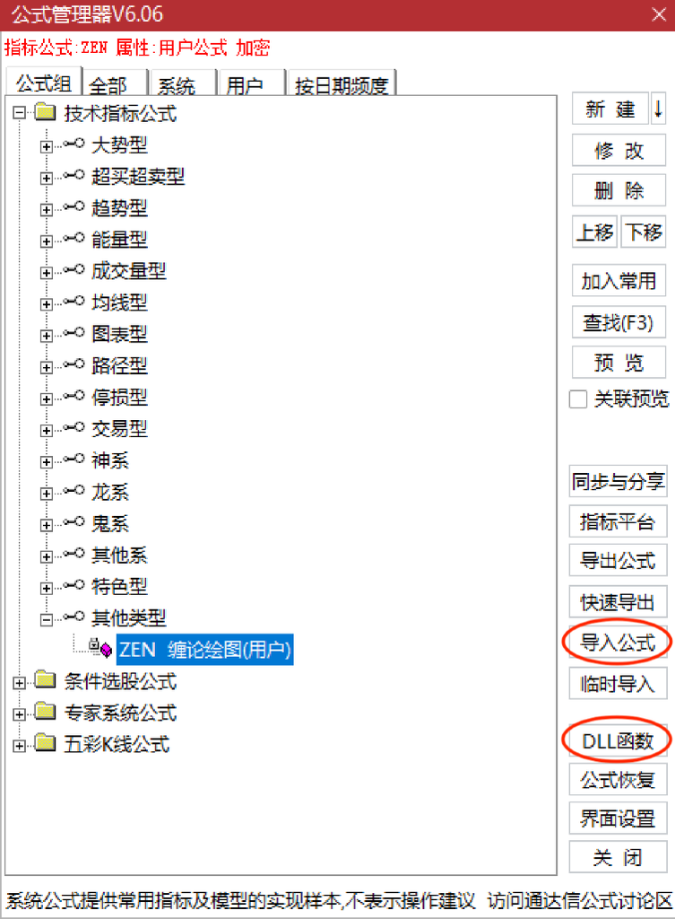

在下拉框中找到标有 **“第2号”** 的插槽，点击 **“打开绑定”** 按钮，浏览到 `T0002\dlls\` 子目录，选中 `tdx_zen.dll` 后点击“打开”：

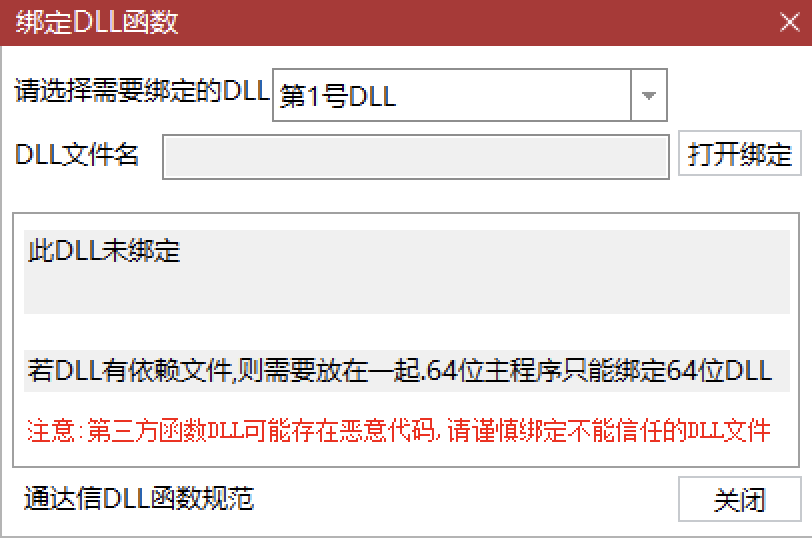

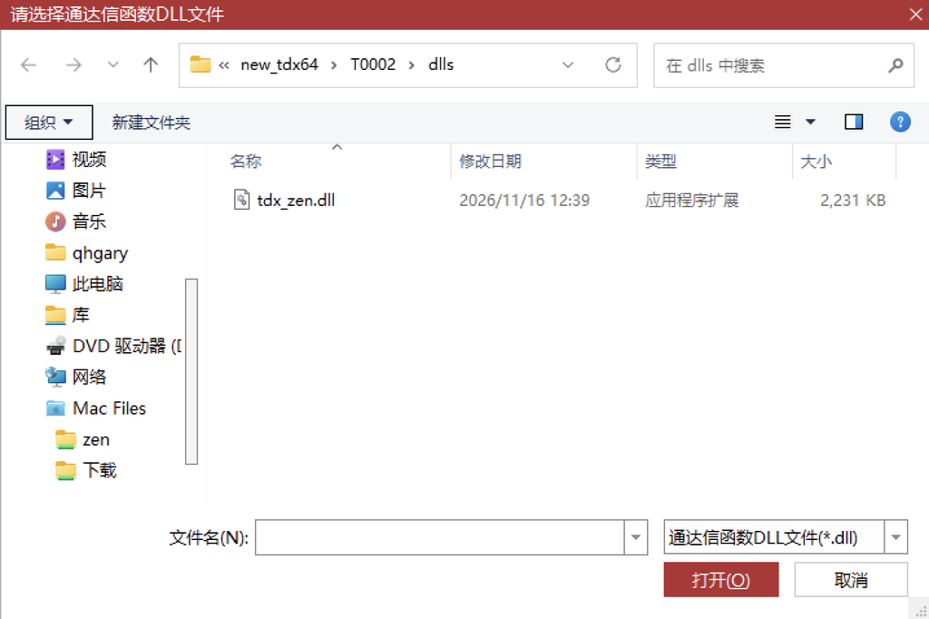

此时可能会弹出安全提示，这是通达信对第三方插件的常规提示，只要下载来源为官方作者即可放心点击确认。

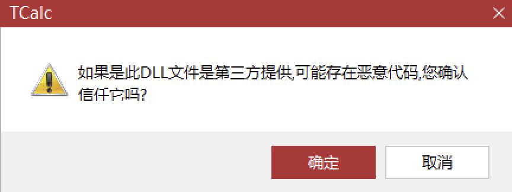

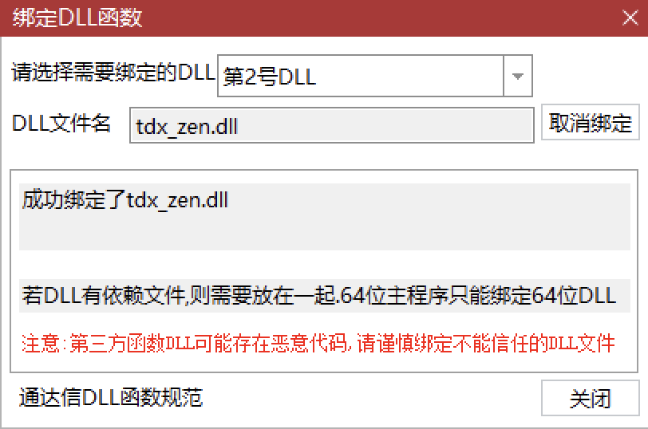

首次绑定时，会弹出浏览器展示用户协议。只有阅读完全文并点击同意后方能使用本插件。**同一版协议正文只展示一次**：只有软件升级且新版改动过协议正文时才会再次弹窗征求同意，协议正文未变的升级不会重复弹出。点击协议最下方的"同意"后，第 2 号插槽会显示 `tdx_zen.dll`。

如果是试用软件，此时会弹窗显示剩余试用天数提醒。

⬆ 回到目录

### 附录 A.4 通达信盘后数据下载说明

**下载步骤**：

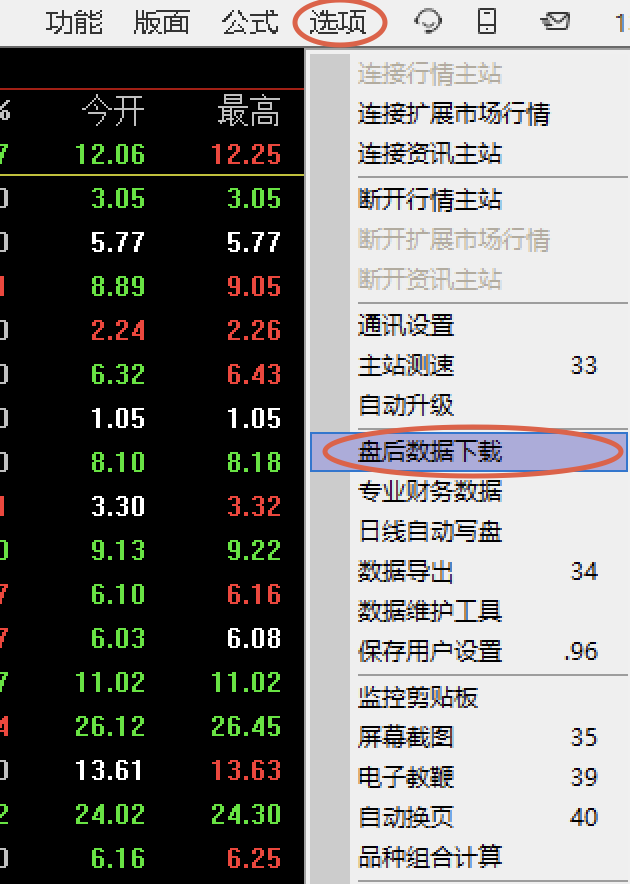

2. 在弹出的下载界面中，根据需要选择下载内容：
   - **日线数据**：勾选"沪深京日线"，下载所有 A 股的日线数据
   - **5 分钟线数据**：勾选"沪深京分钟线"下的 **"5 分钟线数据"**（无需下载 1 分钟线，这是通达信软件自身的机制，5 倍数的分钟线通过 5 分钟线生成）
   - 点击 **"开始下载"** 即可

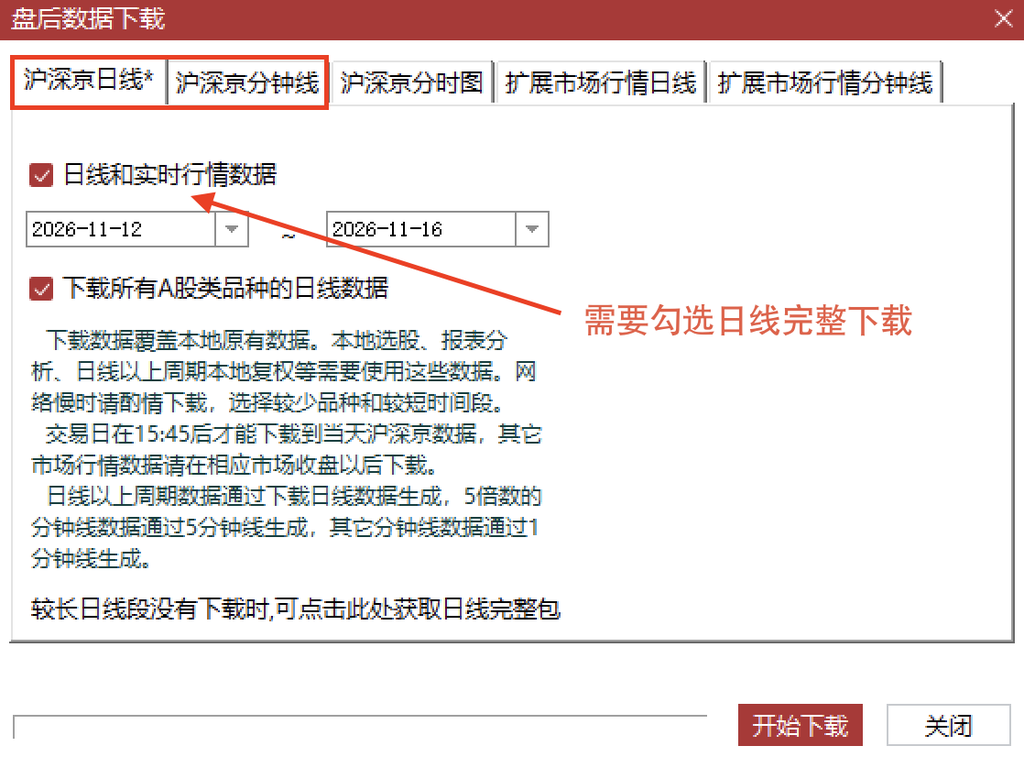

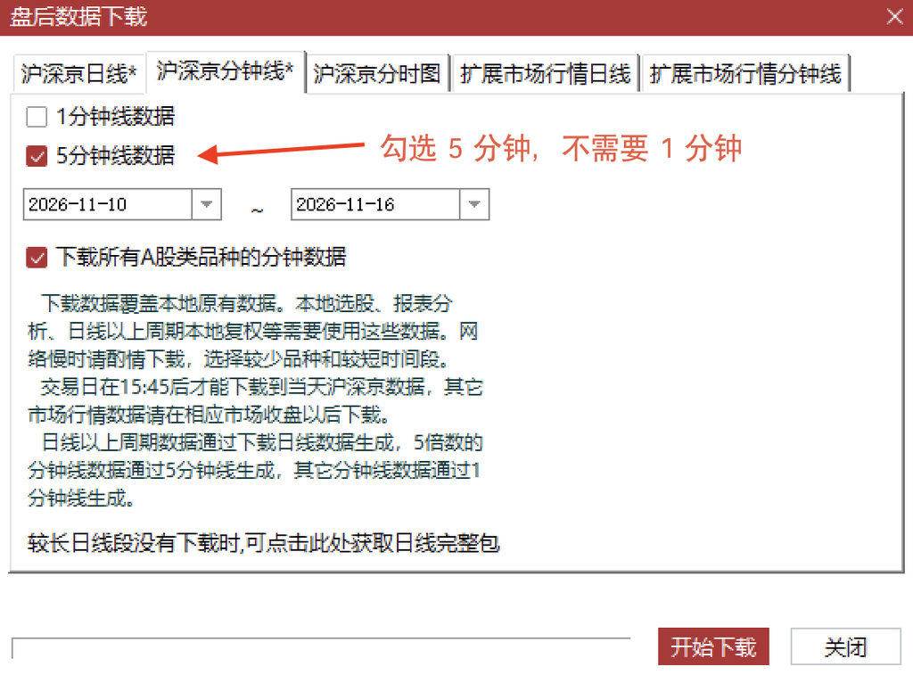

⬆ 回到目录